# Contingency Tables

Math 445, Spring 2017

## A Permutation test for independence of two variables

### Motivating example

The General Social Survey (GSS) is a sociological survey used to collect data on demographic characteristics and attitudes of residents of the United States. In 2014, the survey collected responses from 2538 respondents. We will consider two questions from this survey:

- Do you think the use of marijuana should be made legal, or not?
- What is the highest degree that you have earned?

| degree | legal | not legal | (all) | % in favor |
| --- | --- | --- | --- | --- |
| bachelor | 68 | 41 | 109 | 0.6238532 |
| graduate | 167 | 121 | 288 | 0.5798611 |
| HIGH SCHOOL | 84 | 129 | 213 | 0.3943662 |
| JUNIOR COLLEGE | 446 | 344 | 790 | 0.5645570 |
| (all) | 765 | 635 | 1400 | 0.5464286 |

### Expected counts in R

To calculate the expected counts for use in a hypothesis test we first need to create a basic contingency table:

```r
observed_tbl <- with(grass_df, table(degree, grass))
```

|  | legal | NOT LEGAL |
| --- | --- | --- |
| bachelor | 68 | 41 |
| graduate | 167 | 121 |
| HIGH SCHOOL | 84 | 129 |
| JUNIOR COLLEGE | 446 | 344 |

Then we use the function `outer` to take the outer product of the row and column totals vectors:

```r
expected_tbl <- outer(rowSums(observed_tbl), colSums(observed_tbl)) / sum(observed_tbl)
```

|  | legal | NOT LEGAL |
| --- | --- | --- |
| bachelor | 59.56071 | 49.43929 |
| graduate | 157.37143 | 130.62857 |
| HIGH SCHOOL | 116.38929 | 96.61071 |
| JUNIOR COLLEGE | 431.67857 | 358.32143 |

Finally, we can calculate our test statistic:

```r
sum((observed_tbl - expected_tbl)^2 / expected_tbl)
```

```
## [1] 24.85484
```

### Algorithm

Store the data in a table with one row per observation and one column per variable.

Calculate a test statistic for the original data. Normally large values of the test statistic suggest dependence.

**Repeat**

Randomly permute the rows in one of the columns.

Calculate the test statistic for the permuted data.

**Until** we have enough samples

Calculate the $p$-value as the fraction of times the random statistics exceed the original statistic.

Optionally, plot a histogram of the resampled statistic values.

### Implementation in R

We’ll use the `chisq` function written by the authors. Notice that the input is a contingency table, which can be obtained using the `table` command.

```r
chisq <- function(obs) {
  expected <- outer(rowSums(obs), colSums(obs)) / sum(obs)
  RES <- sum((obs - expected)^2 / expected)
  return(RES)
}
```

Extract the columns of the data frame that correspond to the categories of interest (this simplifies checking for errors). We don’t need to do this in our example, since we only have two columns in the `grass_df` data frame.

```r
# Notice the NAs
summary(grass_df)
```

```
##        grass                degree
##  legal    :870   bachelor      : 186
##  NOT LEGAL:704   graduate      : 472
##  NA's     :964   HIGH SCHOOL   : 330
##                  JUNIOR COLLEGE:1269
##                  NA's          : 281
```

```r
# Exclude the missing values
grass_complete <- na.omit(grass_df)

# Check that it worked
summary(grass_complete)
```

```
##        grass                degree
##  legal    :765   bachelor      :109
##  NOT LEGAL:635   graduate      :288
##                  HIGH SCHOOL   :213
##                  JUNIOR COLLEGE:790
```

Now we’re ready to permute the data. Remember that in each step we need to:

- Randomly permute the rows in one of the columns.
- Calculate the test statistic for the permuted data.

```r
# make sure dplyr is loaded for the sample_n function
N <- 10^4 - 1
result <- numeric(N)
grass2 <- grass_complete$grass
degree2 <- grass_complete$degree
for(i in 1:N) {
  grass_permuted <- sample(grass2)
  gss_tbl <- table(degree2, grass_permuted)
  result[i] <- chisq(gss_tbl)
}
```

Now that we have the reference distribution we can inspect it using a histogram

```r
library(ggplot2)
ggplot(data = data.frame(stats = result)) +
  geom_histogram(mapping = aes(stats))
```

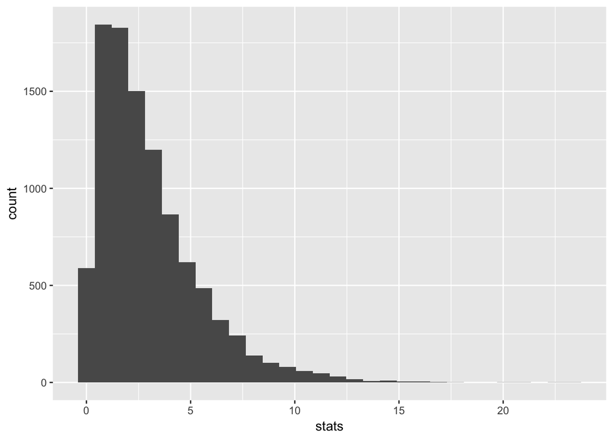

[figure not shown]

and calculate a p-value

```r
# Calculating the p-value
(sum(result >= chisq(observed_tbl)) + 1) / (N + 1)
```

```
## [1] 3e-04
```

What does the $p$-value indicate?

## Using the $\chi^2$ distribution

Below is the histogram of the reference distribution from our permutation test with a $\chi^2_3$ density curve overlaid.

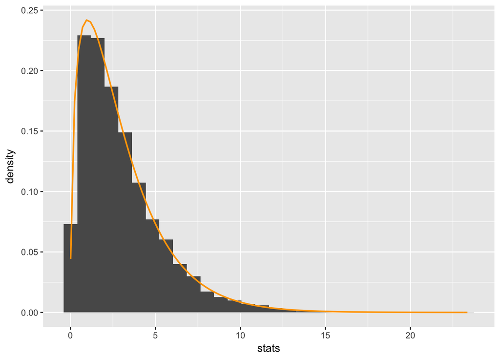

[figure not shown]

It is easy to calculate a $p$-value from a $\chi^2_m$ distribution using the `pchisq` function (i.e., the CDF):

```r
1 - pchisq(24.85, df = 3)
```

```
## [1] 1.659666e-05
```

R can easily perform all of the calculations required for this hypothesis test in one simple function:

```r
chisq.test(grass_df$degree, grass_df$grass)
```

```
##
##  Pearson's Chi-squared test
##
## data:  grass_df$degree and grass_df$grass
## X-squared = 24.855, df = 3, p-value = 1.656e-05
```